# Section 3.3 Confidence Intervals for One Mean

Last updated Thursday, October 08, 2026 @ 05:40 PM

## Before We Begin…

These slides are meant to accompany the text [*Introduction to Statistical Investigations, 2nd Edition*](http://www.isi-stats.com/isi/index2nd.html) — Section 3.3 2SD and Theory Based Confidence Intervals for a Single Mean.

*This content does not replace reading the relevant textbook section.* It is for class presentation, review, and reference.

## Recall: The Spiral Process & Four Pillars

- We addressed strength of evidence (significance) in Chapter 1. ✔ *Good job!*
- We addressed breadth of results (generalization) in Chapter 2. ✔ *Great work!*
- **We will learn about *size* for an effect (estimation) in Chapter 3.**
- Chapter 4 will introduce the idea of causation, the last of the four pillars.

## Learning Goals for Chapter 3

Chapter 3 focuses on *estimation*. We can estimate how large an effect is using an *interval* of statistically likely or plausible values.

- Construct and interpret a confidence interval for a single population proportion using the range of plausible values technique. [Section 3.1]
- Construct and interpret a confidence interval for a single population proportion using both 2SD and theory-based methods. [Section 3.2]
- Construct and interpret a confidence interval for a single population mean using both 2SD and theory-based methods. [Section 3.3]
- Identify how factors (confidence level, sample size, SD) affect the width of the confidence interval. [Section 3.4]

## Learning Goals for Section 3.3

In Section 3.3, you will extend what you learned about creating confidence intervals for population proportions in Section 3.2 to confidence intervals for population means.

- Approximate a 95% confidence interval for a mean by using the 2SD method.
- Compute a confidence interval for a mean using a theory-based approach, including checking validity conditions.

## Section 3.3 Not-So-New Vocabulary

Recall, you learned about \(SD(\bar{x})\)—the standard deviation of a \(\bar{x}\) statistic—and the Central Limit Theorem in Section 2.2

**2SD method :** we can approximate a 95% confidence interval (*if the sampling distribution of a statistic is approximately normal*) by taking the statistic and the SD of the statistic and extending the interval 2 SDs in each direction from the statistic…

\[\text{for example: } \bar{x} \pm 2 \times SD(\bar{x})\]

**margin of error :** the half-width of a confidence interval; for the 2SD method, this is the ± 2SD component

**standard error / SE :** an estimate of the standard deviation of a statistic that is based on observed data

## The Two Standard Deviation Method

Calculate the observed sample proportion \(\bar{x}\).

Approximate the standard deviation of the sampling distribution of \(\bar{x}\) using what we learned from the Central Limit Theorem and using the sample value \(s\) to estimate \(\sigma\).

\[SD(\bar{x}) = s / \sqrt(n)\]

Plug the values into the equation below to get an approximate 95% confidence interval for \(\mu\), based on the sample data.

\[\bar{x} \pm 2 \times SD(\bar{x})\]

Look familiar? It should—this is the same logic we used for \(\pi\).

## Empirical Rule: Why the 2SD Works

For a roughly bell-shaped curve, about 95% of the distribution will be within ±2SD of the mean—the basis of the 2SD method. The 2SD method is valid as long as the sampling distribution is symmetric and roughly bell-shaped.

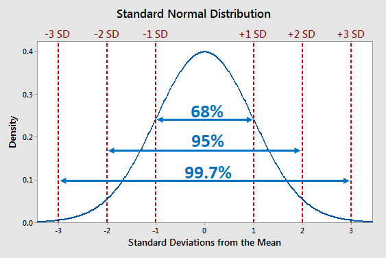

We could also create 68% and 99.7% CIs using ±1SD and ±3SD.

## The CLT: Why the Theory Works

We know from the Central Limit Theorem that if our sample size is 20 or more, and the distribution is not too skewed, then the sampling distribution of \(\bar{x}\) will be approximately Normal.

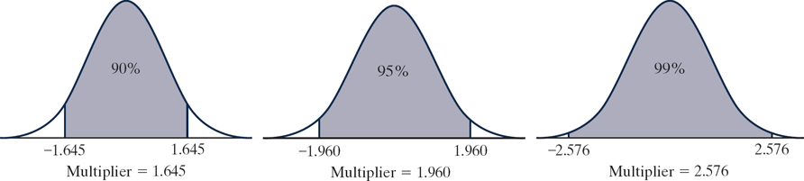

If we knew the population standard deviation \(\sigma\), we could use the Normal curve like we did with proportions. However, if we estimate \(\sigma\) using sample value \(s\), then we will need to use the *t* distribution instead. We will use technology to get these values.

## The Theory-Based Method

Calculate the observed sample proportion \(\bar{x}\).

Approximate the standard deviation of the sampling distribution of \(\bar{x}\) using what we learned from the Central Limit Theorem and using the sample value \(s\) to estimate \(\sigma\).

\[SD(\bar{x}) = s / \sqrt(n)\]

Plug the values into the equation below to get a 95% confidence interval for \(\mu\), based on the sample data. The correct multiplier will be found from the appropriate *t* distribution (\(df = n - 1\)). This is called a one-sample *t*-interval.

\[\bar{x} \pm t\text{ multiplier} \times SD(\bar{x})\]